# Week 10 - Day 03 - Homework

# First predictor

```r
model_1a <- lm(price ~ sqft_living, data = prices_candidates)
model_1b <- lm(price ~ yr_built, data = prices_candidates)
model_1c <- lm(price ~ grade, data = prices_candidates)
```

```r
summary(model_1a)
```

```
Call:
lm(formula = price ~ sqft_living, data = prices_candidates)

Residuals:
     Min       1Q   Median       3Q      Max
-1476062  -147486   -24043   106182  4362067

Coefficients:
              Estimate Std. Error t value Pr(>|t|)
(Intercept) -43580.743   4402.690  -9.899   <2e-16 ***
sqft_living    280.624      1.936 144.920   <2e-16 ***
---
Signif. codes:  0 ‘***’ 0.001 ‘**’ 0.01 ‘*’ 0.05 ‘.’ 0.1 ‘ ’ 1

Residual standard error: 261500 on 21611 degrees of freedom
Multiple R-squared:  0.4929,    Adjusted R-squared:  0.4928
F-statistic: 2.1e+04 on 1 and 21611 DF,  p-value: < 2.2e-16
```

```r
summary(model_1b)
```

```
Call:
lm(formula = price ~ yr_built, data = prices_candidates)

Residuals:
    Min      1Q  Median      3Q     Max
-461709 -221337  -87006  104064 7201095

Coefficients:
             Estimate Std. Error t value Pr(>|t|)
(Intercept) -790477.9   167350.2  -4.723 2.33e-06 ***
yr_built        675.1       84.9   7.952 1.93e-15 ***
---
Signif. codes:  0 ‘***’ 0.001 ‘**’ 0.01 ‘*’ 0.05 ‘.’ 0.1 ‘ ’ 1

Residual standard error: 366600 on 21611 degrees of freedom
Multiple R-squared:  0.002917,  Adjusted R-squared:  0.002871
F-statistic: 63.23 on 1 and 21611 DF,  p-value: 1.93e-15
```

```r
summary(model_1c)
```

```
Call:
lm(formula = price ~ grade, data = prices_candidates)

Residuals:
     Min       1Q   Median       3Q      Max
-1929615  -135853   -35090    89080  5565658

Coefficients:
            Estimate Std. Error t value Pr(>|t|)
(Intercept)   142000     254499   0.558 0.576878
grade3         63667     293870   0.217 0.828484
grade4         72381     258849   0.280 0.779767
grade5        106524     255024   0.418 0.676169
grade6        159920     254561   0.628 0.529868
grade7        260590     254513   1.024 0.305904
grade8        400853     254520   1.575 0.115285
grade9        631513     254547   2.481 0.013112 *
grade10       929771     254611   3.652 0.000261 ***
grade11      1354842     254817   5.317 1.07e-07 ***
grade12      2049222     255909   8.008 1.23e-15 ***
grade13      3567615     264106  13.508  < 2e-16 ***
---
Signif. codes:  0 ‘***’ 0.001 ‘**’ 0.01 ‘*’ 0.05 ‘.’ 0.1 ‘ ’ 1

Residual standard error: 254500 on 21601 degrees of freedom
Multiple R-squared:  0.5197,    Adjusted R-squared:  0.5195
F-statistic:  2125 on 11 and 21601 DF,  p-value: < 2.2e-16
```

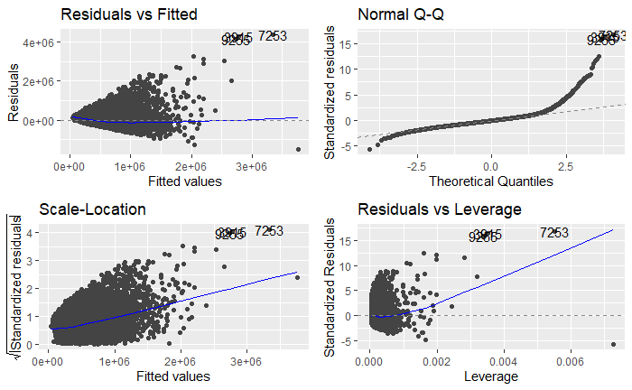

```r
autoplot(model_1a)
```

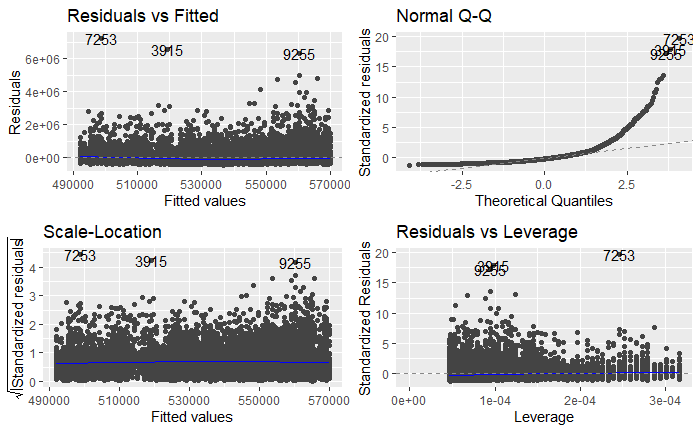

```r
autoplot(model_1b)
```

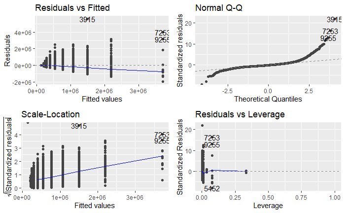

```r
autoplot(model_1c)
```

After performing a log transformation on price, these problems decreased.

# Second Predictor

[figure not shown]

```r
model_2a <- lm(log(price) ~ sqft_living + lat, data = prices_candidates)
model_2b <- lm(log(price) ~ sqft_living + waterfront, data = prices_candidates)
model_2c <- lm(log(price) ~ sqft_living + grade, data = prices_candidates)
```

```r
summary(model_2a)
```

```
Call:
lm(formula = log(price) ~ sqft_living + lat, data = prices_candidates)

Residuals:
     Min       1Q   Median       3Q      Max
-3.00396 -0.19459 -0.01122  0.18293  1.24316

Coefficients:
              Estimate Std. Error t value Pr(>|t|)
(Intercept) -6.256e+01  7.239e-01  -86.42   <2e-16 ***
sqft_living  3.863e-04  2.297e-06  168.17   <2e-16 ***
lat          1.573e+00  1.522e-02  103.31   <2e-16 ***
---
Signif. codes:  0 ‘***’ 0.001 ‘**’ 0.01 ‘*’ 0.05 ‘.’ 0.1 ‘ ’ 1

Residual standard error: 0.3097 on 21610 degrees of freedom
Multiple R-squared:  0.6542,    Adjusted R-squared:  0.6542
F-statistic: 2.045e+04 on 2 and 21610 DF,  p-value: < 2.2e-16
```

```r
summary(model_2b)
```

```
Call:
lm(formula = log(price) ~ sqft_living + waterfront, data = prices_candidates)

Residuals:
     Min       1Q   Median       3Q      Max
-2.90243 -0.28303  0.01682  0.26106  1.27143

Coefficients:
                Estimate Std. Error t value Pr(>|t|)
(Intercept)    1.223e+01  6.320e-03 1934.61   <2e-16 ***
sqft_living    3.926e-04  2.790e-06  140.73   <2e-16 ***
waterfrontTRUE 6.301e-01  2.961e-02   21.28   <2e-16 ***
---
Signif. codes:  0 ‘***’ 0.001 ‘**’ 0.01 ‘*’ 0.05 ‘.’ 0.1 ‘ ’ 1

Residual standard error: 0.3746 on 21610 degrees of freedom
Multiple R-squared:  0.4941,    Adjusted R-squared:  0.4941
F-statistic: 1.055e+04 on 2 and 21610 DF,  p-value: < 2.2e-16
```

```r
summary(model_2c)
```

```
Call:
lm(formula = log(price) ~ sqft_living + grade, data = prices_candidates)

Residuals:
     Min       1Q   Median       3Q      Max
-1.63935 -0.25462 -0.00143  0.23511  1.41830

Coefficients:
             Estimate Std. Error t value Pr(>|t|)
(Intercept) 1.180e+01  3.511e-01  33.610  < 2e-16 ***
sqft_living 2.194e-04  4.110e-06  53.370  < 2e-16 ***
grade3      1.504e-01  4.054e-01   0.371 0.710574
grade4      2.327e-01  3.571e-01   0.652 0.514636
grade5      3.076e-01  3.518e-01   0.874 0.381882
grade6      4.824e-01  3.512e-01   1.374 0.169537
grade7      6.659e-01  3.511e-01   1.896 0.057922 .
grade8      8.568e-01  3.512e-01   2.440 0.014712 *
grade9      1.058e+00  3.513e-01   3.012 0.002600 **
grade10     1.230e+00  3.515e-01   3.501 0.000465 ***
grade11     1.367e+00  3.519e-01   3.884 0.000103 ***
grade12     1.509e+00  3.537e-01   4.266 2.00e-05 ***
grade13     1.586e+00  3.655e-01   4.340 1.43e-05 ***
---
Signif. codes:  0 ‘***’ 0.001 ‘**’ 0.01 ‘*’ 0.05 ‘.’ 0.1 ‘ ’ 1

Residual standard error: 0.3511 on 21600 degrees of freedom
Multiple R-squared:  0.5559,    Adjusted R-squared:  0.5557
F-statistic:  2253 on 12 and 21600 DF,  p-value: < 2.2e-16
```

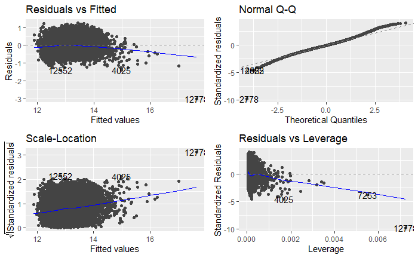

```r
autoplot(model_2a)
```

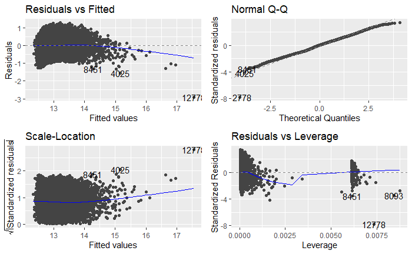

```r
autoplot(model_2b)
```

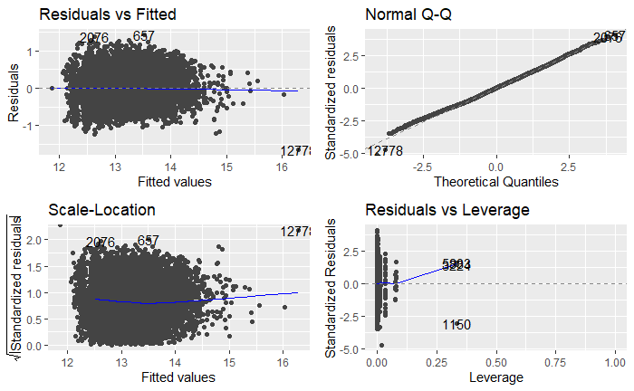

```r
autoplot(model_2c)
```

Our current best model for house price is

log(price) ~ sqft_living + lat

## Model Interpretation

The price of a house in King County can be explained by a combination of it’s size (sqft of the living space) and its latitude (how far north it is)

e.g For a house that’s 1910 sqft (living space) located at lat = 47.56

log(price) = -62.56 + (3.863e-04 * 1910) + (1.573 * 47.56) = 12.98971 price = e^(12.98971)  
= 437884.3 =~ 440,000

```r
model_2a
```

```
Call:
lm(formula = log(price) ~ sqft_living + lat, data = prices_candidates)

Coefficients:
(Intercept)  sqft_living          lat
 -6.256e+01    3.863e-04    1.573e+00
```